# Exercise 2

Yotam Nir

17 4 2021

## Linear Regression

### Preface

We cannot use the data for prediction without assumptions, because some assumptions regarding the data generating process are needed in order to give credibility to the external validity of our results.

#### Separability

The addition of interactions (and in general of additional variables which are functions of original variables) increases the variance of the estimates, thus decreasing their credibility when making predictions.

#### Normal Distribution of $E(u|X)$

##### 1

- $E(u|X) = 0$: the assumption that the expectation of $u$ is zero is innocuous, and can be ensured by choosing the right constant (i.e. $\beta_0$). The assumption that $u$ is mean independent of $X$ is stronger and is never likely to be correct, since there are always likely to be certain unobserved variables that are correlated both with $y$ and with one of the $x$’s. A popular example is “ability bias” in Mincer equations.
- Normal distribution: this is often a reasonable assumption, both asymptotically and because a random variable that is constructed from a variety of other random variables, such as $u$, tends to be normally distributed. Still, we could imagine a particularly dominant factor in $u$ the distribution of which is not normal and which doesn’t quickly converge asymptotically to normal.
- Heteroskedasticity: homoskedasticity does not seem to be a reasonable default assumption. It is often even necessarily wrong, as in the case of binary outcome variables.

##### 2

Conditional on the $x$’s, the variance of $y$ is just that of $u$ (since it is the only random variable left). And since the $\beta$s are a linear function of $y$, this means that they too are normally distributed.

### Data

##### 1

```r
if (!require("pacman")) install.packages("pacman")
pacman::p_load(tidyverse, DataExplorer, tidymodels, kableExtra, ROCit, glmnet)
winequality <- read.csv("winequality_red.csv") %>%
  as_tibble()
```

##### 2

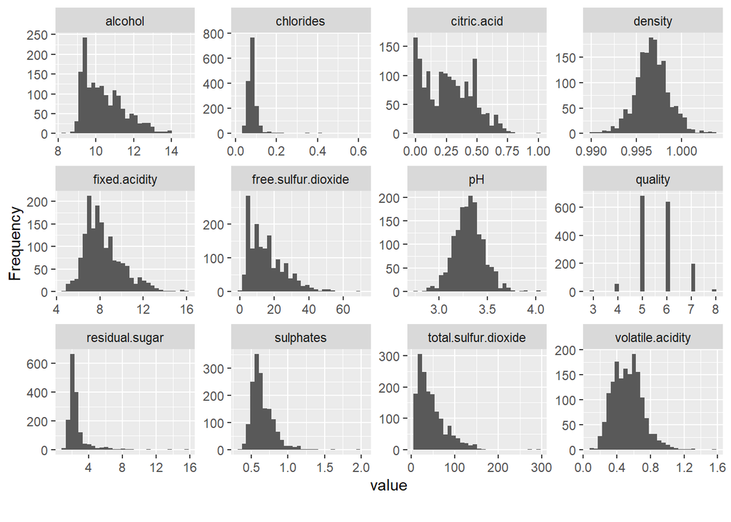

```r
plot_histogram(winequality)
```

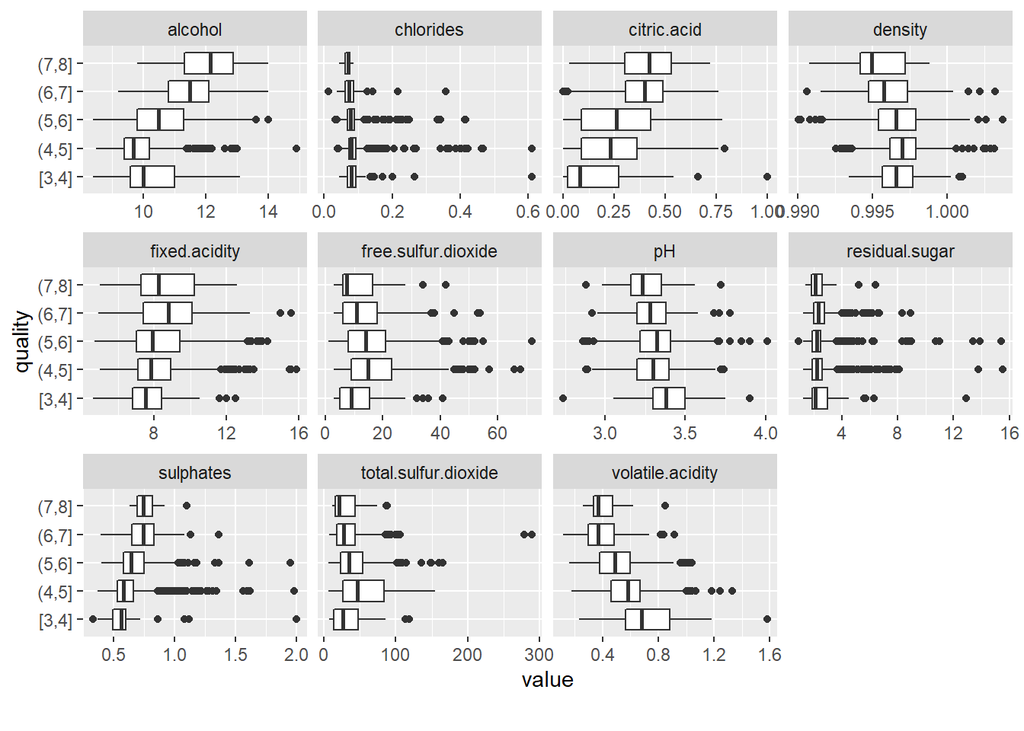

```r
plot_boxplot(winequality, by = "quality")
```

### Model

##### 1

```r
set.seed(100)
winequality_split <- winequality %>%
  initial_split(prop = 0.7)
wine_train <- training(winequality_split)
wine_test <- testing(winequality_split)
```

##### 2

```r
wine_lin <- linear_reg() %>%
  set_engine("lm")
wine_fit <- wine_lin %>%
  fit(quality ~ ., data = wine_train)
wine_fit %>% tidy()
```

```
## # A tibble: 12 x 5
##    term                  estimate std.error statistic  p.value
##    <chr>                    <dbl>     <dbl>     <dbl>    <dbl>
##  1 (Intercept)           18.3     26.2          0.699 4.84e- 1
##  2 fixed.acidity          0.0259   0.0320       0.810 4.18e- 1
##  3 volatile.acidity      -1.17     0.152       -7.70  2.95e-14
##  4 citric.acid           -0.202    0.180       -1.12  2.63e- 1
##  5 residual.sugar         0.0221   0.0186       1.19  2.36e- 1
##  6 chlorides             -2.25     0.532       -4.23  2.56e- 5
##  7 free.sulfur.dioxide    0.00380  0.00267      1.42  1.55e- 1
##  8 total.sulfur.dioxide  -0.00316  0.000864    -3.65  2.72e- 4
##  9 density              -14.1     26.7         -0.529 5.97e- 1
## 10 pH                    -0.401    0.237       -1.69  9.07e- 2
## 11 sulphates              0.966    0.142        6.82  1.49e-11
## 12 alcohol                0.267    0.0329       8.12  1.20e-15
```

##### 3

```r
wine_pred <- wine_fit %>%
  predict(new_data = wine_test) %>%
  bind_cols(wine_test) %>%
  select(quality, .pred)
head(round(wine_pred))
```

```
## # A tibble: 6 x 2
##   quality .pred
##     <dbl> <dbl>
## 1       5     5
## 2       5     5
## 3       6     6
## 4       5     5
## 5       5     6
## 6       5     5
```

##### 4

```r
wine_pred %>%
  rmse(quality, .pred)
```

```
## # A tibble: 1 x 3
##   .metric .estimator .estimate
##   <chr>   <chr>          <dbl>
## 1 rmse    standard       0.609
```

```r
wine_pred %>%
  mae(quality, .pred)
```

```
## # A tibble: 1 x 3
##   .metric .estimator .estimate
##   <chr>   <chr>          <dbl>
## 1 mae     standard       0.475
```

```r
wine_pred %>%
  rsq_trad(quality, .pred)
```

```
## # A tibble: 1 x 3
##   .metric  .estimator .estimate
##   <chr>    <chr>          <dbl>
## 1 rsq_trad standard       0.377
```

##### 5

The coefficients’ confidence intervals are a measure of the model’s variance, while the RMSE is a measure of how much of the variation in $y$ the model can account for. A narrow confidence interval is useful for demonstrating the relationship between two variables, but it might still not account for some other influences on $y$ and therefore does not guarantee good prediction. A low RMSE, on the other hand, does not say much about the relationship between two variables, but is good for prediction.

## Logistic Regression

We can use linear regression for binary outcomes – for example, the linear probability model, where the $\hat{y}$ represents the probability assigned to the outcome conditional on the x’s (even though it is not technically bounded between 0 and 1).

### Data

##### 1

```r
heart <- read.csv("heart.csv") %>%
  as_tibble()
head(heart)
```

```
## # A tibble: 6 x 14
##     age   sex    cp trestbps  chol   fbs restecg thalach exang oldpeak slope
##   <int> <int> <int>    <int> <int> <int>   <int>   <int> <int>   <dbl> <int>
## 1    63     1     3      145   233     1       0     150     0     2.3     0
## 2    37     1     2      130   250     0       1     187     0     3.5     0
## 3    41     0     1      130   204     0       0     172     0     1.4     2
## 4    56     1     1      120   236     0       1     178     0     0.8     2
## 5    57     0     0      120   354     0       1     163     1     0.6     2
## 6    57     1     0      140   192     0       1     148     0     0.4     1
## # ... with 3 more variables: ca <int>, thal <int>, target <int>
```

##### 2

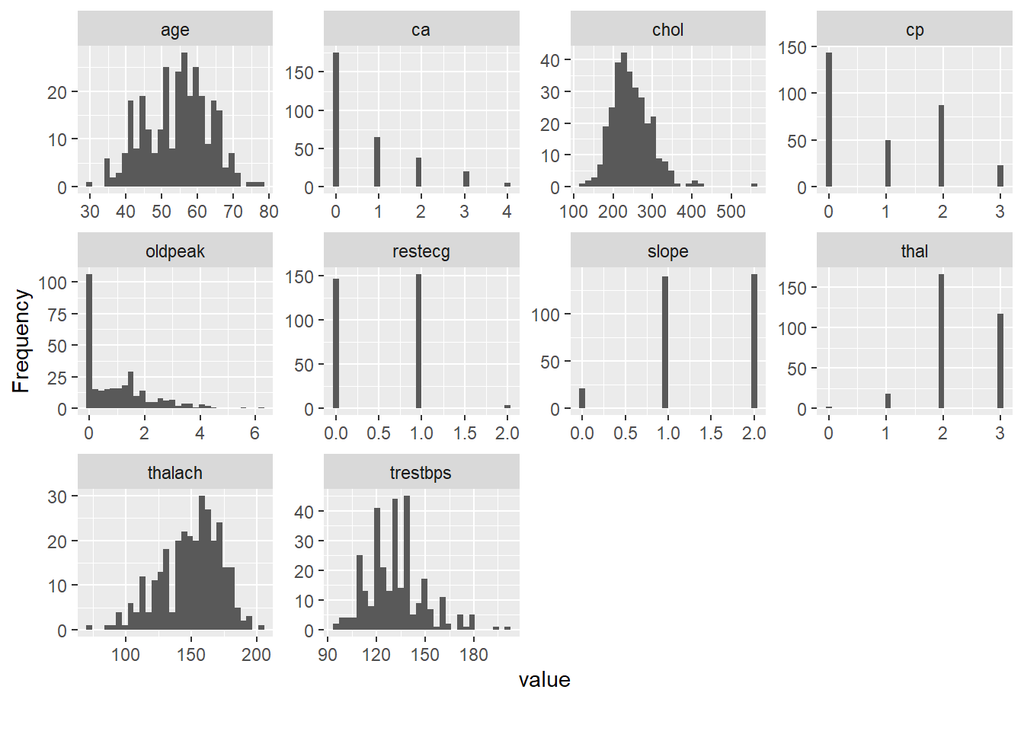

```r
plot_histogram(heart)
```

#### Linear Regression

##### 1

```r
heart_split <- heart %>%
  initial_split(prop = 0.7)
heart_train <- training(heart_split)
heart_test <- testing(heart_split)
```

##### 2

```r
heart_lin <- linear_reg() %>%
  set_engine("lm")
heart_fit <- heart_lin %>%
  fit(target ~ ., data = heart_train)
heart_fit %>% tidy()
```

```
## # A tibble: 14 x 5
##    term         estimate std.error statistic    p.value
##    <chr>           <dbl>     <dbl>     <dbl>      <dbl>
##  1 (Intercept)  0.903     0.365       2.48   0.0141
##  2 age         -0.00128   0.00330    -0.389  0.698
##  3 sex         -0.241     0.0590     -4.09   0.0000636
##  4 cp           0.128     0.0279      4.59   0.00000800
##  5 trestbps    -0.00295   0.00158    -1.86   0.0644
##  6 chol        -0.000554  0.000518   -1.07   0.286
##  7 fbs          0.00530   0.0740      0.0717 0.943
##  8 restecg      0.0368    0.0495      0.744  0.458
##  9 thalach      0.00323   0.00146     2.21   0.0285
## 10 exang       -0.112     0.0639     -1.75   0.0812
## 11 oldpeak     -0.0709    0.0315     -2.25   0.0255
## 12 slope        0.0663    0.0534      1.24   0.216
## 13 ca          -0.0738    0.0272     -2.71   0.00726
## 14 thal        -0.0730    0.0438     -1.67   0.0968
```

##### 3

```r
heart_pred <- heart_fit %>%
  predict(new_data = heart_test) %>%
  bind_cols(heart_test) %>%
  select(target, .pred)
heart_pred %>%
  filter(.pred %in% range(.pred))
```

```
## # A tibble: 2 x 2
##   target  .pred
##    <int>  <dbl>
## 1      1  1.19
## 2      0 -0.335
```

Numbers below 0 or above 1 cannot represent probabilities.

##### 4

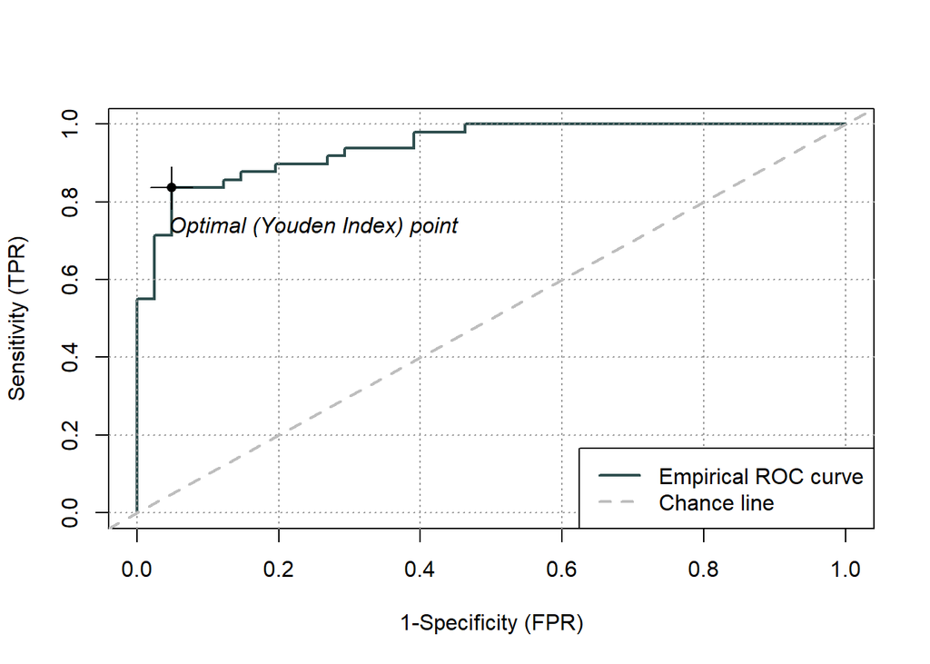

```r
rocit(score = heart_pred$.pred, class = heart_pred$target) %>%
  plot()
```

#### Logistic Regression

##### 1

```r
logit_model <- glm(formula = target ~ ., family = "binomial", data = heart_train)
logit_model %>% tidy()
```

```
## # A tibble: 14 x 5
##    term        estimate std.error statistic   p.value
##    <chr>          <dbl>     <dbl>     <dbl>     <dbl>
##  1 (Intercept)  3.99      3.01       1.32   0.185
##  2 age         -0.0142    0.0271    -0.526  0.599
##  3 sex         -2.04      0.541     -3.76   0.000170
##  4 cp           0.939     0.222      4.22   0.0000239
##  5 trestbps    -0.0256    0.0126    -2.03   0.0426
##  6 chol        -0.00609   0.00419   -1.45   0.146
##  7 fbs         -0.0236    0.584     -0.0405 0.968
##  8 restecg      0.320     0.406      0.787  0.431
##  9 thalach      0.0260    0.0131     1.99   0.0470
## 10 exang       -0.705     0.485     -1.45   0.146
## 11 oldpeak     -0.547     0.262     -2.08   0.0373
## 12 slope        0.428     0.403      1.06   0.289
## 13 ca          -0.515     0.211     -2.44   0.0147
## 14 thal        -0.546     0.341     -1.60   0.109
```

##### 2

```r
logit_heart_pred <- logit_model %>%
  predict(heart_test, type = "response") %>%
  bind_cols(heart_test) %>%
  select(target, ...1)
```

```
## * NA -> ...1
```

```r
logit_heart_pred %>%
  filter(...1 %in% range(...1))
```

```
## # A tibble: 2 x 2
##   target    ...1
##    <int>   <dbl>
## 1      1 0.996
## 2      0 0.00159
```

This time, the numbers are bounded between 0 and 1, as we would like them to be.

##### 3

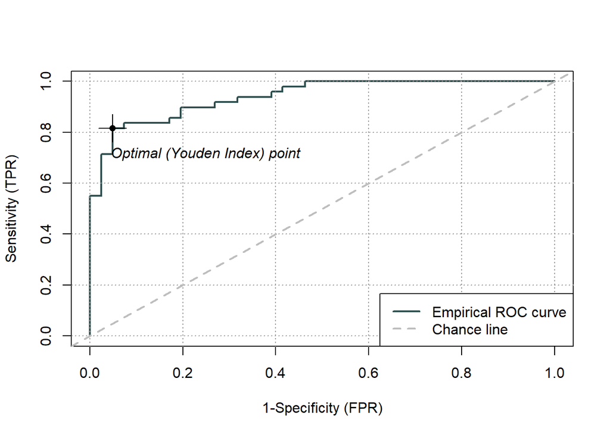

```r
rocit(score = logit_heart_pred$...1, class = logit_heart_pred$target) %>%
    plot()
```

```r
class_rule <- 0.8
logit_heart_pred <- logit_heart_pred %>%
  mutate(
    .fitted_class = if_else(...1 < class_rule, 0, 1),
    .fitted_class = as_factor(.fitted_class) ,
    target = as_factor(target)
  )
heart_conf_mat <- logit_heart_pred %>%
  conf_mat(target, .fitted_class)
heart_conf_mat %>%
  summary() %>%
  filter(.metric %in% c("accuracy", "sens", "spec")) %>%
  mutate("1-.estimate" = 1 - .estimate)
```

```
## # A tibble: 3 x 4
##   .metric  .estimator .estimate `1-.estimate`
##   <chr>    <chr>          <dbl>         <dbl>
## 1 accuracy binary         0.789        0.211
## 2 sens     binary         0.976        0.0244
## 3 spec     binary         0.633        0.367
```

## Regularization

### Ridge

##### 1

If we hadn’t done so, positive and negative coefficients would have cancelled each other out to some extent, leading to an under-representation of the model’s complexity.

##### 2

This is due to the penalty function used in ridge – a Euclidean norm – which creates a rounded “budget constraint”.

### Heart Data

##### 1

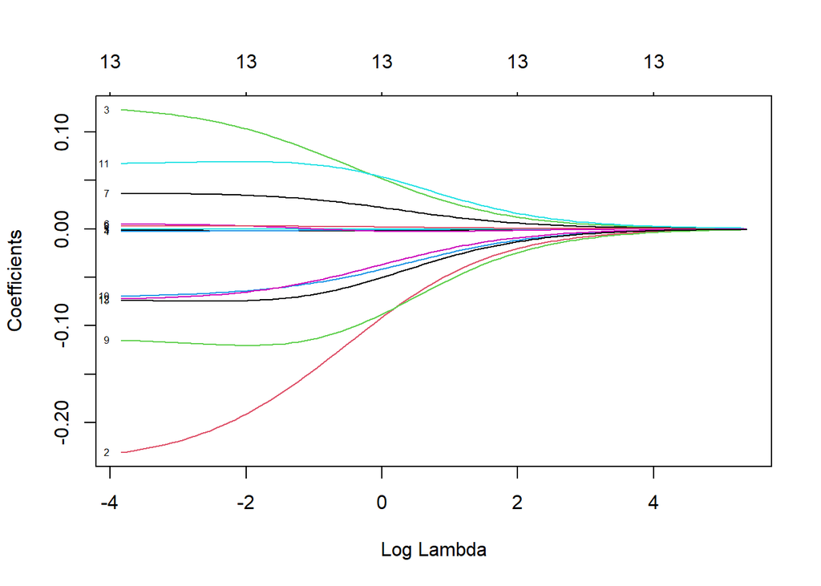

```r
heart_mat <- heart_train %>%
  as.matrix()
Y_heart <- heart_mat[,14]
X_heart <- heart_mat[,1:13]
fit_ridge <- glmnet(X_heart, Y_heart, alpha = 0)
plot(fit_ridge, xvar = "lambda", label = TRUE)
```

##### 2

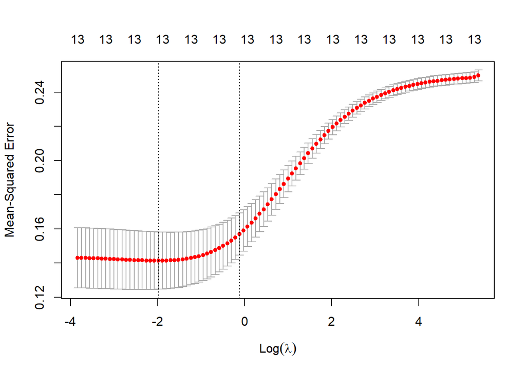

```r
cv_ridge <- cv.glmnet(X_heart, Y_heart, alpha = 0)
plot(cv_ridge, xvar = "lambda", label = TRUE)
```

##### 3

```r
coef(cv_ridge, s = "lambda.min") %>%
  tidy() %>%
  as_tibble()
```

```
## # A tibble: 14 x 3
##    row         column     value
##    <chr>       <chr>      <dbl>
##  1 (Intercept) 1       0.843
##  2 age         1      -0.00207
##  3 sex         1      -0.191
##  4 cp          1       0.103
##  5 trestbps    1      -0.00221
##  6 chol        1      -0.000385
##  7 fbs         1       0.00283
##  8 restecg     1       0.0346
##  9 thalach     1       0.00285
## 10 exang       1      -0.120
## 11 oldpeak     1      -0.0638
## 12 slope       1       0.0693
## 13 ca          1      -0.0650
## 14 thal        1      -0.0741
```

##### 4

This generates bias, due to some of the covariate’s effect being wrongly attributed to the explanatory variable that was included.

##### 5

```r
heart_test_mat <- heart_test %>%
  as.matrix()
X_heart_test <- heart_test_mat[,1:13]
ridge_pred <- predict(cv_ridge, s = "lambda.min", newx = X_heart_test, type = "response") %>%
  bind_cols(heart_test) %>%
  rename(lambda.min = ...1)
ridge_pred <- predict(cv_ridge, s = "lambda.1se", newx = X_heart_test, type = "response") %>%
  bind_cols(ridge_pred) %>%
  rename(lambda.1se = ...1)
cbind(ridge_pred[,1:2], logit_heart_pred$...1) # (lambda.1se, lambda.min, logit)
```

```
##             1            1 logit_heart_pred$...1
## 1  0.57433140  0.593621797           0.651188018
## 2  0.58707983  0.576803516           0.553127061
## 3  0.69209015  0.762352473           0.867999176
## 4  0.69660048  0.737783570           0.808713112
## 5  0.74211561  0.899195691           0.974228050
## 6  0.54169316  0.641264802           0.804918825
## 7  0.59679565  0.553087121           0.425557218
## 8  0.49609592  0.449944762           0.320367363
## 9  0.69226442  0.778878518           0.897686935
## 10 0.57591957  0.669193870           0.890085011
## 11 0.70962130  0.759306963           0.823489724
## 12 0.72249223  0.791433317           0.867459055
## 13 0.85999371  1.080483755           0.995878232
## 14 0.82050201  1.003106684           0.985353578
```

[output cut: 76 more lines]

I am afraid it is not clear in what sense we should compare the results.

##### 6

```r
ridge_pred <- ridge_pred %>%
  mutate(
    class_1se = if_else(lambda.1se < 0.5, 0, 1),
    class_1se = as_factor(class_1se),
    class_min = if_else(lambda.min < 0.5, 0, 1),
    class_min = as_factor(class_min),
    target = as_factor(target)
  )
conf_mat(ridge_pred, target, class_min)
```

```
##           Truth
## Prediction  0  1
##          0 36  6
##          1  5 43
```

```r
conf_mat(ridge_pred, target, class_1se)
```

```
##           Truth
## Prediction  0  1
##          0 33  5
##          1  8 44
```